# Figures - Species-wide phylogenomics of the Staphylococcus aureus agr operon reveals convergent evolution of frameshift mutations

Vishnu Raghuram

10/26/2021

### Load libraries

```r
  setwd("D:/OneDrive - Emory University/TR/Other stuff/agr_project/mSpectrum revision code/")

library(Biostrings)
library(dplyr)
library(viridis)
library(scales)
library(cowplot)
library(ggplot2)
library(hrbrthemes)
library(gggenes)
library(devtools)
library(extrafont)
library(svglite)
library(MASS)
library(emmeans)
library(tidyverse)
library(ggtree)
library(svglite)
library(ggtext)
library(ape)
library(ggnewscale)
library(phytools)
library(RColorBrewer)


axistextx<-20
axistexty<-20
axistitlex<-20
axistitley<-20
legendtext<-20
legendtitle<-20
```

### Fig 1

##### Agrvate summary results and Staphopia metadata

```r
info<-read.table("Fig1/agrvate_metadata.tab",header = T, sep="\t",na.strings = c("","NA"),stringsAsFactors=FALSE, quote="", fill=FALSE)
#info$fs<-as.factor(info$fs)
row.names(info)<-info$acc
info$CC[info$CC!="CC1" & info$CC!="CC130" & info$CC!="CC15" & info$CC!="CC22" & info$CC!="CC30" & info$CC!="CC398" & info$CC!="CC45" & info$CC!="CC5" & info$CC!="CC8" & info$CC!="CC95"] <-"Other"
```

#### Fig 1B: Get distribution of agr groups across Staphopia

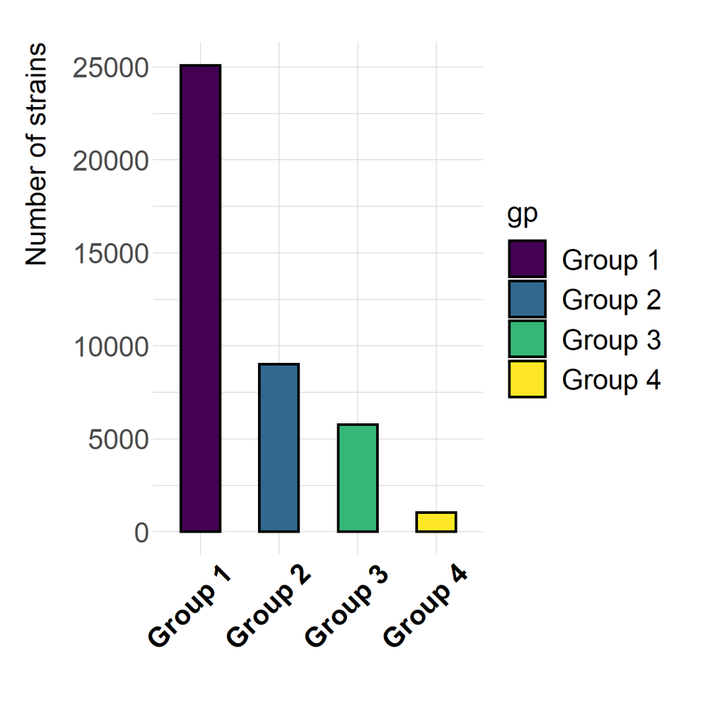

```r
Fig1B<-ggplot(data=info,aes(x=gp,fill=gp))+
  geom_bar(stat="count",color="black",width = 0.5,size=1,position=position_dodge()) +
  theme_ipsum(base_family = "Arial")+
  scale_fill_manual(limits=c("gp1","gp2","gp3","gp4"),labels=c("Group 1","Group 2","Group 3","Group 4"),values=c(viridis(4))) +
  theme(axis.text.x = element_text(angle=45,size = axistextx,vjust=0.7,hjust=0.7,color="black",face="bold"),axis.text.y=element_text(size=axistexty)) +
  theme(axis.title.y=element_text(size=axistitley,color="black",vjust=4))+
  theme(legend.position = "right",legend.text=element_text(size=legendtext),legend.key.size = unit(1, 'cm'),legend.title = element_text(size=legendtitle)) +
  ylab("Number of strains") + xlab("") +
  scale_x_discrete(labels=c("Group 1","Group 2","Group 3","Group 4"))

ggsave("Fig1/Fig1B.svg",plot=Fig1B,device="svg",width = 8,height = 5)

Fig1B
```

#### Fig 1C: Distribution of agr groups across predominant CCs

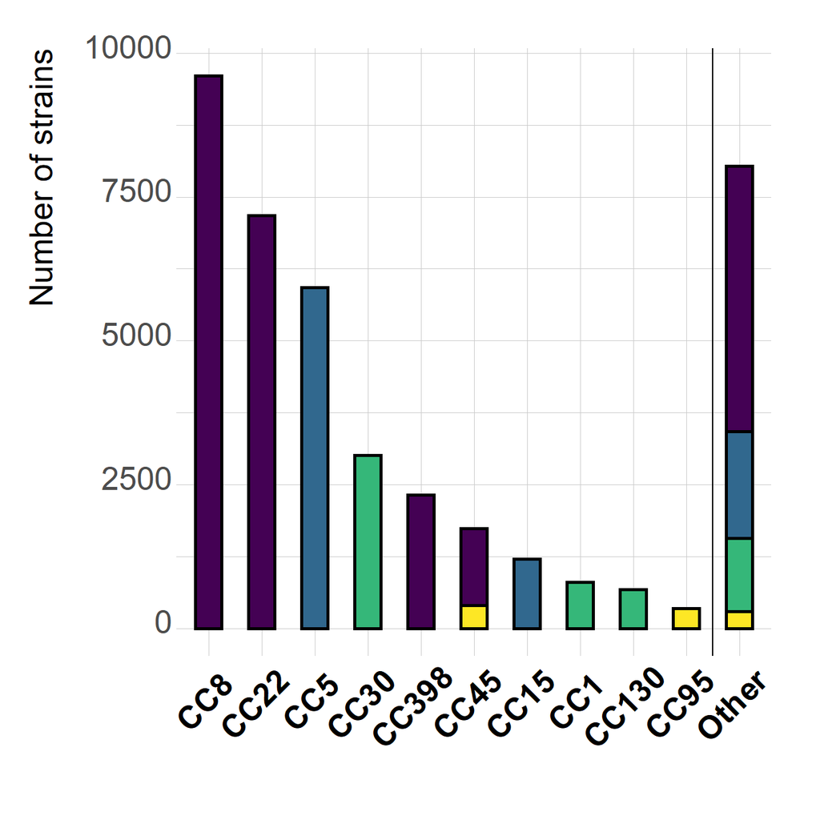

```r
Fig1C<-ggplot(data=info,aes(x=forcats::fct_infreq(CC),fill=gp))+
  geom_bar(stat="count",color="black",width = 0.5,size=1) +
  theme_ipsum(base_family = "Arial")+
  scale_fill_manual(limits=c("gp1","gp2","gp3","gp4"),labels=c("Group 1","Group 2","Group 3","Group 4"),values=c(viridis(4))) +
  theme(axis.text.x = element_text(angle=45,size = axistextx,vjust=0.7,hjust=0.7,color="black",face="bold"),axis.text.y=element_text(size=axistexty,vjust=0.2)) +
  theme(axis.title.y=element_text(size=axistitley,color = "black",vjust=4))+ theme(legend.position = "none") +
  ylab("Number of strains") + xlab("")+
  geom_vline(xintercept = 10.5)+
  scale_x_discrete(limits=c("CC8","CC22","CC5","CC30","CC398","CC45","CC15","CC1","CC130","CC95","Other"))

ggsave("Fig1/Fig1C.svg",plot=Fig1C,device="svg",width=9,height=7)

Fig1C
```

##### Get blood, nares, skin and respiratory isolate data from metadata table and calculate relative proportions

```r
x<-data.frame(subset(info[(info$host_body_site.y == "blood" | info$host_body_site.y == "nares" | info$host_body_site.y == "skin or soft tissue" | info$host_body_site.y == "respiratory" ),],!is.na(host_body_site.y)) %>% group_by(host_body_site.y,gp) %>% summarize(n=n()) %>% mutate(freq=n/sum(n)))
```

#### Fig 1D: Distribution of agr groups across blood, nares, respiratory and skin isolates

```r
library(chisq.posthoc.test)
#chisq test contingency table
contable<-as.data.frame(pivot_wider(x[,c(1,2,3)],names_from = c(host_body_site.y),values_from = n))
row.names(contable)<-contable$gp
chisq.test(contable[,c(2,3,4)])
```

```
##
##  Pearson's Chi-squared test
##
## data:  contable[, c(2, 3, 4)]
## X-squared = 654.28, df = 6, p-value < 2.2e-16
```

```r
chisq.posthoc.test(contable[,c(2,3,4)])
```

```
##   Dimension     Value      blood      nares respiratory
## 1       gp1 Residuals  11.674690 -1.8648252  -14.744685
## 2       gp1  p values   0.000000  0.7464710    0.000000
## 3       gp2 Residuals -15.058054 -0.6385602   23.667536
## 4       gp2  p values   0.000000  1.0000000    0.000000
## 5       gp3 Residuals   4.186354  3.0938317  -11.034913
## 6       gp3  p values   0.000340  0.0237110    0.000000
## 7       gp4 Residuals  -1.183882  2.5260920   -2.074829
## 8       gp4  p values   1.000000  0.1384070    0.456028
```

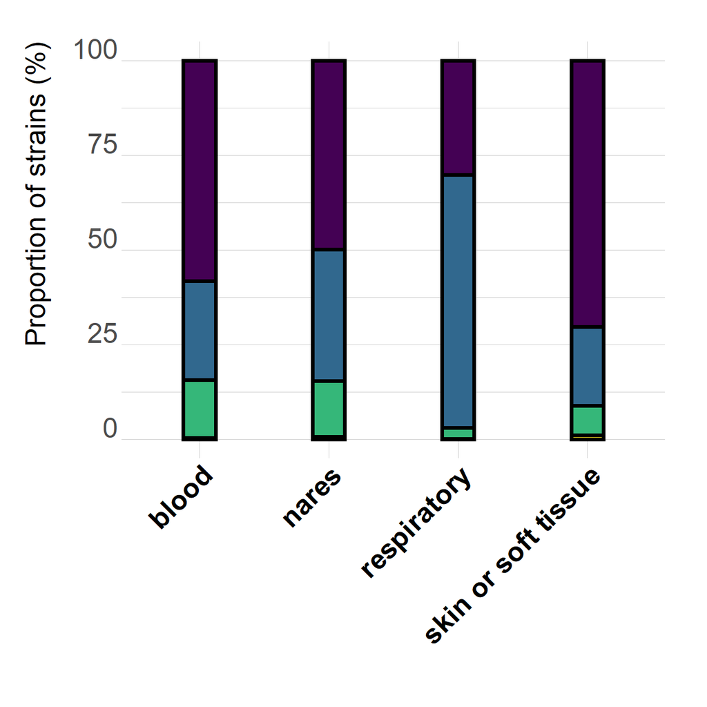

```r
Fig1D<-ggplot(data=x,aes(fill=gp))+
  geom_bar(aes(x=as.factor(host_body_site.y),y=freq*100),stat="identity",color="black",width = 0.25,size=1.25) +
  scale_fill_manual(limits=c("gp1","gp2","gp3","gp4"),labels=c("Group 1","Group 2","Group 3","Group 4"),values=c(viridis(4)))+
  theme_ipsum(base_family = "Arial") +
  scale_fill_manual(values =c(viridis(4))) +
  theme(axis.text.x = element_text(angle=45,size = axistextx,vjust=1,hjust=1,color="black",face="bold"),axis.text.y=element_text(size=axistexty,vjust=-0.1)) +
  theme(axis.title.y=element_text(color = "black",size=axistitley,vjust = 4))+
  ylab("Proportion of strains (%)") +
  xlab("") +
  theme(legend.position = "none")
ggsave("Fig1/Fig1D.svg",plot=Fig1D,device="svg")
Fig1D
```

### Fig 2

#### Fig 2A: No. of agr groups in each agr AA seq cluster

##### Read AgrA uclust table and get number of agr groups in each cluster for each agr gene

```r
dat_AA<-read.table("Fig2/agr_operon_typing_AA_filteredCCs.tab",header = T,sep="\t")

dat_long<-(gather(dat_AA,gene,agr_type,AgrA_repacc:AgrC_repacc,factor_key=T))

x_summary<-dat_long %>% group_by(agr_type,gene,gp) %>% summarize(n=n()) %>% mutate(total=sum(n)) %>% filter(total>10)
agr_gene_spec<-as.data.frame(table(x_summary$agr_type,x_summary$gene))

agr_gene_spec<-distinct(merge(agr_gene_spec,x_summary[,c("agr_type","gene","total")],by.x=c("Var1","Var2"),by.y=c("agr_type","gene")))
```

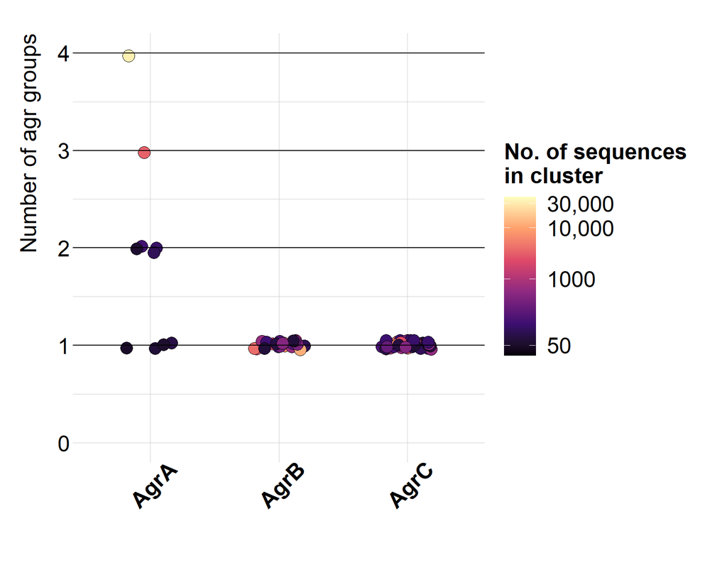

```r
set.seed(10)
Fig2A<-ggplot(data=agr_gene_spec[agr_gene_spec$Freq!=0 & agr_gene_spec$total >50,])+
  geom_jitter(aes(x=Var2,y=Freq,fill=log10(total)),width=0.2,height=0.05,shape=21,color="black",size=5)+
 labs(fill="No. of sequences\nin cluster")+
   ylim(0,4)+
  theme_ipsum(base_family = "Arial")+
  labs(x="",y="Number of agr groups")+
  scale_fill_viridis_c(option="magma",limits=c(1.5,4.6),breaks=c(1.69897,3,4,4.477),labels=c("50","1000","10,000","30,000"))+
  geom_hline(yintercept = c(1,2,3,4))+
  scale_x_discrete(labels=c("AgrA","AgrB","AgrC"))+
  theme(axis.text.x=element_text(color="black",size=axistextx,face="bold",angle=45,vjust=0.7))+
  theme(axis.title.y=element_text(color="black",size=axistitley,vjust = 4))+
  theme(axis.text.y=element_text(color="black",size=axistexty))+
  theme(legend.position = "right",legend.text=element_text(size=legendtext),legend.key.size = unit(1, 'cm'),legend.title = element_text(size=legendtitle,face="bold"))


ggsave("Fig2/Fig2A.svg",plot=Fig2A,device="svg")
Fig2A
```

#### Fig 2C: Phylogeny of NRD strains from staphopia showing AgrA AACR type.

#### Read Staphopia NRD set phylogenetic tree, agrA clustering table and NRD AgrVATE summary

```r
agrA_type<-read.table(file="Fig2/agrA_clusterID-acc.txt",sep="\t",header = F,stringsAsFactors = F)
colnames(agrA_type)<-c("agrA_type","acc")
nrd_agr_summary<-read.table(file="Fig2/nrd_agrvate_summary.tab",header=T)
nrd_agr_summary$gp<-ifelse(nrd_agr_summary$multiple_agr=="m","m",nrd_agr_summary$gp)
NRD_CC<-read.table(file="Fig2/NRD_CC.tab",header=F)

x<-merge(nrd_agr_summary,agrA_type,by="acc")
x$agrA_type[x$agrA_type!="337" & x$agrA_type!="283"]<-"Other"
x$agrA_type[x$agrA_type=="337"]<-"agrA-K"
x$agrA_type[x$agrA_type=="283"]<-"agrA-R"
rownames(x)<-x$acc
```

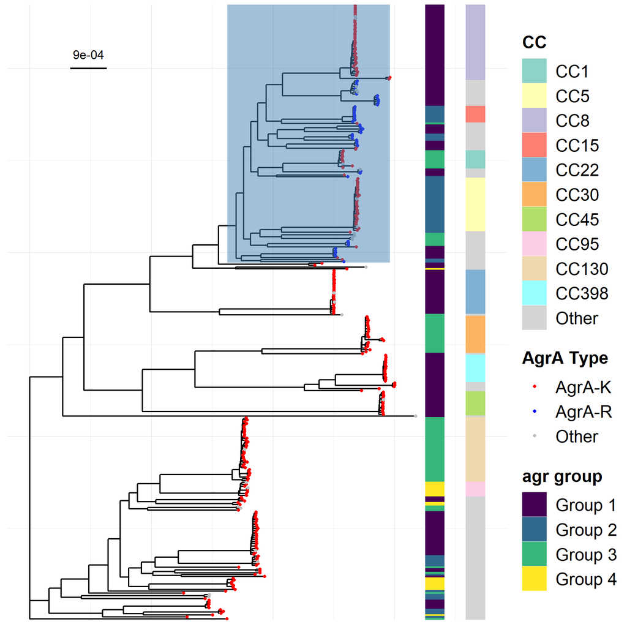

```r
##REVISED TREE FIG 2C

#Root tree at ST93 strain

tree_genome_2<-read.tree(file='Fig2/nrd_genomes_parsnp_prefiltered.mfa.treefile')
tree_genome_2<-drop.tip(tree_genome_2,c("USA300.fna.ref"))
tree_genome_2<-root(tree_genome_2,outgroup = "SRX456475",resolve.root = T)



NRD_CC$V1[NRD_CC$V1!="CC1" & NRD_CC$V1!="CC130" & NRD_CC$V1!="CC15" & NRD_CC$V1!="CC22" & NRD_CC$V1!="CC30" & NRD_CC$V1!="CC398" & NRD_CC$V1!="CC45" & NRD_CC$V1!="CC5" & NRD_CC$V1!="CC8" & NRD_CC$V1!="CC95"] <-"Other"
rownames(NRD_CC)<-NRD_CC$V2


Fig2C_1<-ggtree(tree_genome_2,layout = 'rectangular',branch.length = "1",size=0.8,color="black") %<+% x +
  geom_tippoint(size=1.5,aes(color=agrA_type)) +
  geom_hilight(node = 352)+
  theme(legend.position = "right") +
  guides(shape = guide_legend(override.aes = list(size = 10)))+
  theme_minimal()+
  scale_color_manual("AgrA Type",values=c("red","blue","grey"),labels=c("AgrA-K","AgrA-R","Other"))+
  theme(axis.text=element_text(size=axistextx,color="black"))+
  theme(axis.text = element_blank())+
  theme(legend.position = "right",legend.text=element_text(size=legendtext),legend.key.size = unit(1, 'cm'),legend.title = element_text(size=legendtitle,face="bold"))+
  geom_treescale(x=0.001,y=300, fontsize=5,linesize = 1,offset=5)

Fig2C_2<-gheatmap(Fig2C_1,x[,c("gp"),drop=F],offset=0,width=0.05,colnames = F,color=NULL)+
    scale_fill_manual("agr group",values=c(viridis(4)),limits=c("gp1","gp2","gp3","gp4"),labels=c("Group 1","Group 2","Group 3","Group 4"))+new_scale_fill()
Fig2C<-gheatmap(Fig2C_2,NRD_CC[,c("V1"),drop=F],offset=0.001,width=0.05,colnames=F,color=NULL)+scale_fill_manual("CC",values=c(brewer.pal(8,"Set3"),"wheat2","darkslategray1","grey83"),limits=c("CC1","CC5","CC8","CC15","CC22","CC30","CC45","CC95","CC130","CC398","Other"))
ggsave("Fig2/Fig2C_revised.svg",plot=Fig2C,device="svg",width=10,height=10)

Fig2C
```

#### Fig 2D: LD plot

```r
ld<-read.table("Fig2/plink_snippy_core_full-aln.ld",header=T,sep="\t")

ld <- filter(ld,R2>0.2)
ld <- ld %>% arrange(R2)
ld$x <- ld$BP_A+((ld$BP_B-ld$BP_A)/2)
ld$y <- ld$BP_B-ld$BP_A
ld$r2c <- cut(ld$R2,breaks=seq(0,1,0.2),labels=c("0.0 - 0.2","0.2 - 0.4","0.4 - 0.6","0.6 - 0.8","0.8 - 1.0"))
ld$r2c <- factor(ld$r2c,levels=rev(c("0.0 - 0.2","0.2 - 0.4","0.4 - 0.6","0.6 - 0.8","0.8 - 1.0")))

genes<-read.table(file="Fig2/plink_gggenes.txt",header=T,sep="\t")
```

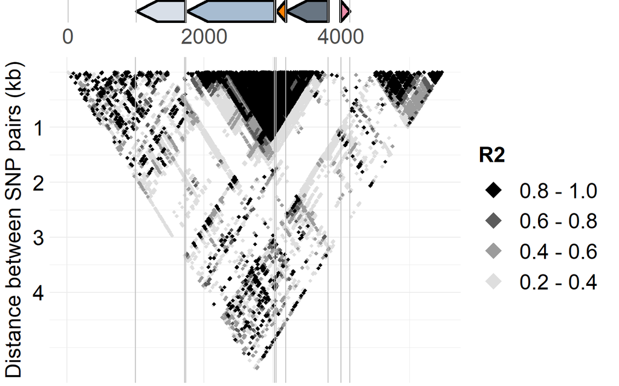

```r
Fig2D_1<-ggplot(ld,aes(x=x,y=-y,color=r2c))+
  geom_point(shape=18,size=1.5)+
  scale_color_manual(values=c("#000000","#5c5c5c","#9c9c9c","#dedede","#FFFFFF"))+
  labs(x="",y="Distance between SNP pairs (kb)")+
  theme_minimal() +
  theme(axis.title.x = element_blank(),axis.title.y = element_text(size=axistitley,color="black",vjust=2),axis.text.y=element_text(size=axistexty,color="black")) +
  theme(legend.position = "right",legend.text=element_text(size=legendtext),legend.key.size = unit(1, 'cm'),legend.title = element_text(size=legendtitle,face="bold")) +
  guides(colour=guide_legend(title="R2",override.aes=list(shape=18,size=7)))+
  theme(plot.margin = unit(c(0,.6,.0,.6),"lines"))+
  theme(axis.text.x=element_blank())+
  geom_vline(xintercept = c(1000,1717,1736,3028,3053,3193,3190,3813,3997,4129),color="grey")+
  scale_y_continuous(breaks = c(-1000,-2000,-3000,-4000),labels=c("1","2","3","4"))


Fig2D_2<-ggplot(data=genes,aes(xmin = start, xmax = end, y = molecule, fill = gene,label=gene)) +
  geom_gene_arrow(data=genes[genes$gene != "hld",],aes(forward=F),color="black",size=1.25,arrowhead_height = unit(7,"mm"), arrowhead_width = unit(7,"mm"),arrow_body_height = unit(7,"mm")) +
  geom_gene_arrow(data=genes[genes$gene == "hld",],aes(forward=T),color="black",size=1.25,arrowhead_height = unit(7,"mm"), arrowhead_width = unit(7,"mm"),arrow_body_height = unit(7,"mm")) +
  scale_fill_manual(values=(c("#D8DFE8","#687582","#A7BCD1","#FF8000","#EB8DA9"))) +
  theme_minimal() +
  theme(axis.text.y = element_blank()) +
  theme(panel.grid.major.x = element_line(color = "grey"),legend.position = "none",panel.grid.minor.x = element_blank()) +
  theme(panel.grid.major.y = element_blank(),panel.grid.minor.y = element_blank()) +
  theme(axis.title.x = element_blank(),axis.title.y = element_blank()) +
  theme(axis.text.x=element_text(size=axistextx))+
  xlim(0,5482)+
  theme(plot.margin = unit(c(0,6,0.6,0.0),"lines"))+
  geom_vline(xintercept = c(1000,1717,1736,3028,3053,3193,3190,3813,3997,4129),color="grey")

Fig2D<-plot_grid(Fig2D_2,Fig2D_1,ncol=1,align="v",rel_heights = c(0.7,4),axis="lrbt")

ggsave("Fig2/Fig2D.svg",plot=Fig2D,device="svg",height = 7,width = 10)

Fig2D
```

### Fig 3

#### Fig 3A: Frequency of frameshifts per site

##### Agrvate variant calling results for agr operon cluster representatives

```r
agrvate_fs<-read.table("Fig3/unique_staphopia_agrvate_2_TRUE_FRAMESHIFTS.tab",sep="\t",header=F,stringsAsFactors=FALSE, quote="", fill=FALSE)
colnames(agrvate_fs)<-c("acc","POS","TYPE","EFFECT","NA_CHANGE","AA_CHANGE","GENE")

#Merge with metadata table
agrvate_fs<-merge(agrvate_fs,info[,c("acc","st","CC","gp","no_fs","address","collection_date","study_accession","sample_accession")],by="acc")

#Read gggenes coordinates table
genes<-read.table(file="Fig3/gp1_gggenes.txt",header=T,sep="\t")
```

```r
Fig3A_1<-ggplot(data=NULL) +
  geom_histogram(data=agrvate_fs,aes(x=POS,fill=gp),color="black",binwidth=40,size=0.5) +
  scale_fill_manual(limits=c("gp1","gp2","gp3","gp4"),values=c(viridis(4))) +
  theme_tinyhand() +
  theme(panel.grid.major.x = element_line(color = "grey"),panel.grid.minor.x = element_blank(),axis.text.x = element_blank()) +
  theme(panel.grid.major.y = element_blank(),panel.grid.minor.y = element_blank()) +
  theme(axis.title.x = element_blank()) +
  theme(axis.title.y=element_text(color="black",size=axistitley,vjust = 4))+
  theme(axis.text.y=element_text(color="black",size=axistexty,hjust=2))+
  theme(legend.position = "none")+
  xlim(-10,3482)+
  ylab("Number of genomes with mutated site")+
  theme(plot.margin = unit(c(.2,0,0.2,0.2),"lines"))


Fig3A_2<-ggplot(data=NULL) +
  geom_gene_arrow(data=genes[genes$gene != "hld",],aes(xmin = start, xmax = end, y = molecule, fill = gene,forward=F),color="black",size=1.25,arrowhead_height = unit(7,"mm"), arrowhead_width = unit(7,"mm"),arrow_body_height = unit(7,"mm")) +
  geom_gene_arrow(data=genes[genes$gene == "hld",],aes(xmin = start, xmax = end, y = molecule, fill = gene,forward=T),color="black",size=1.25,arrowhead_height = unit(7,"mm"), arrowhead_width = unit(7,"mm"),arrow_body_height = unit(7,"mm")) +
  scale_fill_manual(values=(c("#D8DFE8","#687582","#A7BCD1","#FF8000","#EB8DA9"))) +
  theme_minimal() +
  theme(axis.text.y = element_blank()) +
  theme(panel.grid.major.x = element_line(color = "grey"),legend.position = "none",panel.grid.minor.x = element_blank()) +
  theme(panel.grid.major.y = element_blank(),panel.grid.minor.y = element_blank()) +
  theme(axis.title.x = element_blank(),axis.title.y = element_blank())+
  xlim(-10,3482)+
  theme(axis.text.x = element_text(size=axistextx))
  theme(plot.margin = unit(c(.2,0,0.2,0.2),"lines"))
```

```
## List of 1
##  $ plot.margin: 'simpleUnit' num [1:4] 0.2lines 0lines 0.2lines 0.2lines
##   ..- attr(*, "unit")= int 3
##  - attr(*, "class")= chr [1:2] "theme" "gg"
##  - attr(*, "complete")= logi FALSE
##  - attr(*, "validate")= logi TRUE
```

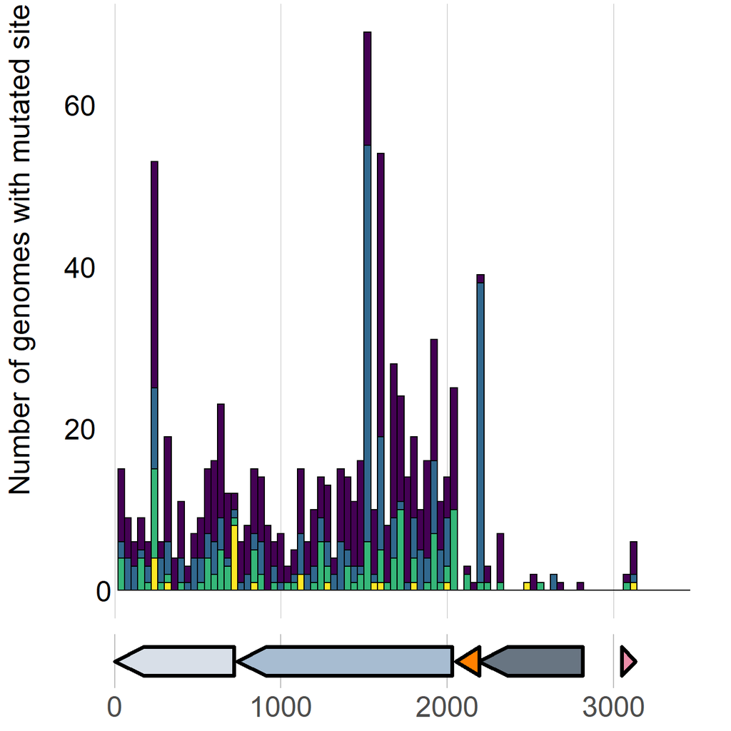

```r
Fig3A<-plot_grid(Fig3A_1,Fig3A_2,ncol=1,align="v",rel_heights = c(3,0.5),axis="bt")

ggsave("Fig3/Fig3A.svg",plot=Fig3A,device="svg",height=7,width=7)

Fig3A
```

#### Fig 3B: Frequency and effect of recurring agr frameshifts

```r
#Get 10 most frequent frameshifts in unique agr operons
variants_10<-agrvate_fs %>% group_by(AA_CHANGE) %>% filter(n() > 20)

#Read gggenes coordinates for 10 most frequent frameshifts in unique agr operons
genes<-read.table(file="Fig3/unique_operons_ggenes_input.txt",header=T,sep="\t")
```

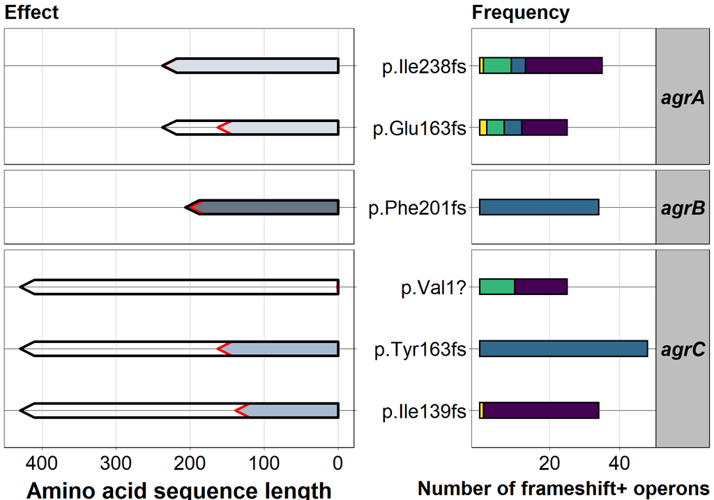

```r
Fig3B_1<-ggplot(data=variants_10,aes(y=AA_CHANGE,fill=gp))+
  geom_bar(stat="count",colour="black",size=0.75,width=0.25) +
  scale_fill_manual(limits=c("gp1","gp2","gp3","gp4"),values=c(viridis(4)))+
  theme_linedraw() +
  theme(axis.text.x = element_text(angle=0,size = axistextx,vjust=0.4,color="black"),axis.text.y=element_text(size=axistexty,color="black")) +
  theme(axis.title.y=element_text(size=axistitley,vjust=1,face="bold")) +

  facet_grid(GENE~.,scales = "free_y",space="free") +
  theme(plot.margin = unit(c(.3,.3,.3,-.8),"lines")) +
  labs(x="",y="") +
  theme(legend.position = "none") +
  theme(panel.grid.major.y = element_line(color="black"))+
  theme(strip.text.y = element_text(size=axistexty,color="black",face="bold.italic",angle=0),strip.background = element_rect(fill="grey"))+
  theme(panel.grid.minor.x = element_blank(),panel.grid.major.x = element_line(color="grey"))+
  theme(axis.title.x = element_text(size=axistitlex,color="black",face="bold",vjust=-0.5))+
  xlab("Number of frameshift+ operons")+
  scale_x_continuous(breaks=c(20,40))+
  ggtitle("Frequency")+
  theme(plot.title=element_text(size=20,face="bold",color="black"))


Fig3B_2<-ggplot(data=genes,aes(xmin=start,xmax=end,y=molecule,forward=T)) +
  geom_gene_arrow(data=genes,aes(xmin=submin,xmax=submax,fill=gene),color="red",size=1.25,arrowhead_height = unit(5,"mm"), arrowhead_width = unit(5,"mm"),arrow_body_height = unit(5,"mm")) +
  geom_gene_arrow(fill=NA,color="black",size=1.25,arrowhead_height = unit(5,"mm"), arrowhead_width = unit(5,"mm"),arrow_body_height = unit(5,"mm")) +
  scale_fill_manual(values=(c("#D8DFE8","#687582","#A7BCD1","#FF8000","#EB8DA9"))) +
  scale_color_manual(values=(c("#D8DFE8","#687582","#A7BCD1","#FF8000","#EB8DA9"))) +
  theme_linedraw() +
  theme(axis.text.y = element_blank()) +
  theme(panel.grid.major.x = element_line(color = "grey"),legend.position = "none",panel.grid.minor.x = element_blank()) +
  theme(panel.grid.major.y = element_blank(),panel.grid.minor.y = element_blank()) +
  theme(axis.title.x = element_text(size=23,color="black",face="bold",vjust=-0.5),axis.title.y = element_blank()) +
  xlab("Amino acid sequence length")+
  facet_grid(gene~.,scales="free_y",space="free") +
  theme(strip.text.y = element_blank())+
  scale_x_reverse() +
  scale_y_discrete(position = "right")+
  theme(plot.margin = unit(c(.3,0,0.3,0.3),"lines")) +
  theme(axis.text.x = element_text(angle=0,size = axistextx,vjust=0.4,color="black"))+
  theme(panel.grid.major.y = element_line(color="black"))+
  ggtitle("Effect")+
  theme(plot.title=element_text(size=20,face="bold",color="black"))

Fig3B<-plot_grid(Fig3B_2,Fig3B_1,ncol=2,align = "h",axis = "bt")

ggsave("Fig3/Fig3B.svg",plot=Fig3B,device="svg",height = 10,width = 10)

Fig3B
```

#### REVISED Fig 3C: Percentage/Counts of variable length TCS genes normalized to 1kb

##### Get number and percentage of variable gene lengths for TCSs calculated from blastn search across Staphopia

```r
HKRR_var<-read.table("Fig3/response_regulator_length-variation.txt",header=T,sep="\t",stringsAsFactors = F)

#Normalize all lengths to 1kb by multiplying with normalization factor
HKRR_var$norm_factor<-1000/HKRR_var$canon_len

#Calculate length normalized percentages
HKRR_var$norm_percentage<-(HKRR_var$variable*HKRR_var$norm_factor*100/HKRR_var$total)
rownames(HKRR_var)<-HKRR_var$gene
```

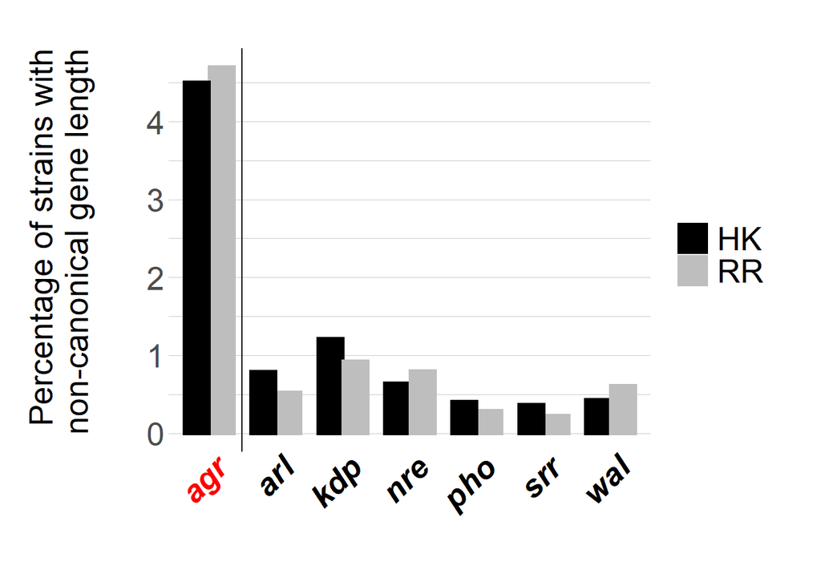

```r
a <- ifelse(HKRR_var$operon == "agr", "red", "black")
Fig3C<-ggplot(data=HKRR_var)+
  geom_bar(aes(x=as.factor(operon),y=(norm_percentage),color=type,fill=type),stat = "identity",width=0.75,size=1,position=position_dodge())+
  scale_color_manual(values=c("black","grey"))+
  scale_fill_manual(values=c("black","grey"))+
  theme_tinyhand() +
  theme(axis.text.x = element_text(face = "bold.italic",angle=45,size = axistextx,margin=margin(t=0,r=0,b=0,l=0),hjust=0.9,color=c("red",rep("black",times=6))),axis.text.y=element_text(size=axistexty)) +
  theme(axis.title.y=element_text(size=axistitley,vjust=4,color="black",margin=margin(t=0,r=20,b=0,l=0)))+
  theme(legend.position = "right",legend.text=element_text(size=legendtext),legend.key.size = unit(0.7, 'cm'),legend.title = element_blank()) +
  theme(panel.grid.major.x = element_blank())+
  ylab("Percentage of strains with\nnon-canonical gene length") + xlab("") +
  geom_vline(xintercept = 1.5)

ggsave("Fig3/Fig3C.svg",plot=Fig3C,device="svg",height = 5,width = 7,units = "in",dpi=600)


Fig3C
```

```r
##### Statistics: RATE MODEL WITH OFFSET for total no. of samples using negative binomial regression

data<-HKRR_var[,c(2,4,5,9,10)]

nb.model<-glm.nb((norm_factor*variable)~operon+offset(log(total)),data)

summary(nb.model)
```

```
##
## Call:
## glm.nb(formula = (norm_factor * variable) ~ operon + offset(log(total)),
##     data = data, init.theta = 49.83483353, link = log)
##
## Deviance Residuals:
##      Min        1Q    Median        3Q       Max
## -1.49695  -1.06460  -0.00099   0.96614   1.30875
##
## Coefficients:
##             Estimate Std. Error z value Pr(>|z|)
## (Intercept)  -3.0775     0.1014 -30.341   <2e-16 ***
## operonarl    -1.9375     0.1486 -13.036   <2e-16 ***
## operonkdp    -1.4563     0.1463  -9.951   <2e-16 ***
## operonnre    -1.8499     0.1481 -12.490   <2e-16 ***
## operonpho    -2.5702     0.1538 -16.714   <2e-16 ***
## operonsrr    -2.7124     0.1554 -17.456   <2e-16 ***
## operonwal    -2.1665     0.1501 -14.432   <2e-16 ***
## ---
## Signif. codes:  0 '***' 0.001 '**' 0.01 '*' 0.05 '.' 0.1 ' ' 1
##
## (Dispersion parameter for Negative Binomial(49.8348) family taken to be 1)
##
##     Null deviance: 581.146  on 13  degrees of freedom
## Residual deviance:  14.694  on  7  degrees of freedom
## AIC: 165.52
##
## Number of Fisher Scoring iterations: 1
##
##
##               Theta:  49.8
##           Std. Err.:  23.4
##
##  2 x log-likelihood:  -149.516
```

```r
marginal<-emmeans(nb.model,~operon)
pairs(marginal)
```

```
##  contrast  estimate    SE  df z.ratio p.value
##  agr - arl   1.9375 0.149 Inf  13.036  <.0001
##  agr - kdp   1.4563 0.146 Inf   9.951  <.0001
##  agr - nre   1.8499 0.148 Inf  12.490  <.0001
##  agr - pho   2.5702 0.154 Inf  16.714  <.0001
##  agr - srr   2.7124 0.155 Inf  17.456  <.0001
##  agr - wal   2.1665 0.150 Inf  14.432  <.0001
##  arl - kdp  -0.4812 0.151 Inf  -3.178  0.0250
##  arl - nre  -0.0876 0.153 Inf  -0.572  0.9976
##  arl - pho   0.6327 0.159 Inf   3.989  0.0013
##  arl - srr   0.7750 0.160 Inf   4.838  <.0001
##  arl - wal   0.2291 0.155 Inf   1.477  0.7586
##  kdp - nre   0.3936 0.151 Inf   2.608  0.1234
##  kdp - pho   1.1139 0.156 Inf   7.118  <.0001
##  kdp - srr   1.2562 0.158 Inf   7.947  <.0001
##  kdp - wal   0.7103 0.153 Inf   4.645  0.0001
##  nre - pho   0.7203 0.158 Inf   4.555  0.0001
##  nre - srr   0.8626 0.160 Inf   5.401  <.0001
##  nre - wal   0.3167 0.155 Inf   2.048  0.3840
##  pho - srr   0.1423 0.165 Inf   0.862  0.9780
##  pho - wal  -0.4036 0.160 Inf  -2.522  0.1511
##  srr - wal  -0.5459 0.162 Inf  -3.379  0.0129
##
## Results are given on the log (not the response) scale.
## P value adjustment: tukey method for comparing a family of 7 estimates
```

### Fig 4

#### Fig 4A: Frequency of frameshift mutations occurring at each position in real vs simulated data in dereplicated set of CC5, CC8, CC22 and CC30 genomes

```r
x<-read.table(file="Fig4/drep_CC_fs_pos_POSITIONS.txt",sep="\t",header=F)
y<-read.table(file="Fig4/simulated_CC_fs_pos_POSITIONS.txt",sep="\t",header=F)
```

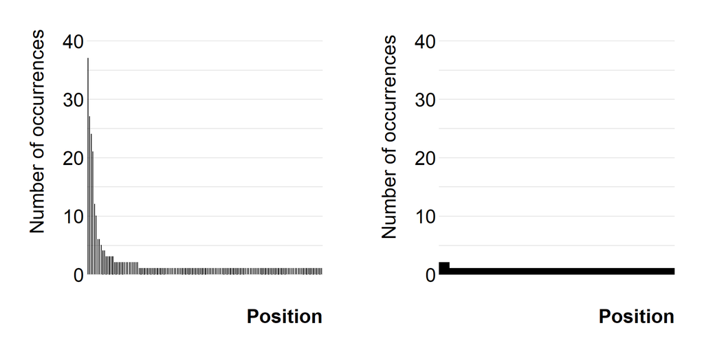

```r
Fig4A_1<-ggplot(data=NULL)+
  geom_bar(data=x,aes(x=forcats::fct_infreq(as.factor(V1))),stat="count",width=0.07,color="black") +
  theme_ipsum(base_family = "Arial") +
    theme(axis.text.x=element_blank())+
  theme(axis.text.y=element_text(size=axistexty,color="black"))+
  theme(axis.title.x=element_text(size=axistitlex,color="black",face="bold",margin = margin(t = 20, r = 0, b = 0, l = 0)))+
  theme(axis.title.y=element_text(size=axistitley,color="black",margin = margin(t = 0, r = 20, b = 0, l = 0)))+
  theme(panel.grid.major.x = element_blank()) +
  labs(x="Position",y="Number of occurrences") +
  ylim(0,40)

Fig4A_2<-ggplot(data=NULL)+
  geom_bar(data=y,aes(x=forcats::fct_infreq(as.factor(V1))),stat="count",width=0.25,color="black") +
  theme_ipsum(base_family = "Arial") +
  theme(axis.text.x=element_blank())+
  theme(axis.text.y=element_text(size=axistexty,color="black"))+
  theme(axis.title.x=element_text(size=axistitlex,color="black",face="bold",margin = margin(t = 20, r = 0, b = 0, l = 0)))+
  theme(axis.title.y=element_text(size=axistitley,color="black",margin = margin(t = 0, r = 20, b = 0, l = 0)))+
  theme(panel.grid.major.x = element_blank()) +
  #theme(axis.text.x = element_blank())+
  labs(x="Position",y="Number of occurrences ") +
  ylim(0,40)

Fig4A<-plot_grid(Fig4A_1,Fig4A_2,ncol=2)

ggsave("Fig4/Fig4A.svg",plot=Fig4A,device="svg",height = 5,width = 10)

Fig4A
```

```r
#Compare real and simulated variant position distributions
ks.test(x$V1,y$V1)
```

```
##
##  Two-sample Kolmogorov-Smirnov test
##
## data:  x$V1 and y$V1
## D = 0.38153, p-value < 2.2e-16
## alternative hypothesis: two-sided
```

#### Fig 4B: Number of frameshifts per site in real and randomized data

##### Read phylogenetic trees from dereplicated CC5, CC8, CC22, CC30 dataset

```r
tree_CC30<-read.tree(file='Fig4/CC30/CC30_parsnp_iqtree.tree')
tree_CC22<-read.tree(file='Fig4/CC22/CC22_parsnp_iqtree.tree')
tree_CC8<-read.tree(file='Fig4/CC8/CC8_parsnp_iqtree.tree')
tree_CC5<-read.tree(file='Fig4/CC5/CC5_parsnp_iqtree.tree')
```

##### Read consistency index report - HomoplasyFinder output for REAL data

```r
CC8_ci<-read.table("Fig4/CC8/consistencyIndexReport_25-02-21.txt",sep="\t",header=T)
CC8_fs_counts<-read.table("Fig4/CC8/CC8_reps_fs_POS_count.txt",sep="\t",header=F)
colnames(CC8_fs_counts)<-c("POS","fs_counts")
CC8_ci<-merge(CC8_ci,CC8_fs_counts,by.x="Start",by.y="POS")
CC8_ci['CC']="CC8"

CC30_ci<-read.table("Fig4/CC30/consistencyIndexReport_25-02-21.txt",sep="\t",header=T)
CC30_fs_counts<-read.table("Fig4/CC30/CC30_reps_fs_POS_count.txt",sep="\t",header=F)
colnames(CC30_fs_counts)<-c("POS","fs_counts")
CC30_ci<-merge(CC30_ci,CC30_fs_counts,by.x="Start",by.y="POS")
CC30_ci['CC']="CC30"

CC22_ci<-read.table("Fig4/CC22/consistencyIndexReport_25-02-21.txt",sep="\t",header=T)
CC22_fs_counts<-read.table("Fig4/CC22/CC22_reps_fs_POS_count.txt",sep="\t",header=F)
colnames(CC22_fs_counts)<-c("POS","fs_counts")
CC22_ci<-merge(CC22_ci,CC22_fs_counts,by.x="Start",by.y="POS")
CC22_ci['CC']="CC22"

CC5_ci<-read.table("Fig4/CC5/consistencyIndexReport_25-02-21.txt",sep="\t",header=T)
CC5_fs_counts<-read.table("Fig4/CC5/CC5_reps_fs_POS_count.txt",sep="\t",header=F)
colnames(CC5_fs_counts)<-c("POS","fs_counts")
CC5_ci<-merge(CC5_ci,CC5_fs_counts,by.x="Start",by.y="POS")
CC5_ci['CC']="CC5"

CC_reps_ci_REAL<-rbind(CC8_ci,CC5_ci,CC22_ci,CC30_ci)
CC_reps_ci_REAL$MinimumNumberChangesOnTree[CC_reps_ci_REAL$MinimumNumberChangesOnTree=="-"]<-0
```

```r
Fig4B_1<-ggplot(data=CC_reps_ci_REAL[CC_reps_ci_REAL$fs_counts>1,])+
  geom_point(aes(x=fs_counts,y=as.numeric(MinimumNumberChangesOnTree),fill=CC),size=4,shape=21,position = position_jitter(width = 0.35,height=0.01),color="black")+
  geom_smooth(method="lm",formula = y ~ x,aes(x=fs_counts,y=as.numeric(MinimumNumberChangesOnTree)))+
  theme_ipsum(base_family = "Arial")+
  scale_x_continuous(breaks=pretty_breaks(n=5))+
  scale_y_continuous(breaks=pretty_breaks(n=5))+
  theme(axis.text.x=element_text(size=axistextx,color="black"))+
  theme(axis.text.y=element_text(size=axistexty,color="black"))+
  theme(axis.title.x=element_text(size=axistitlex,color="black",face="bold",margin = margin(t = 20, r = 0, b = 0, l = 0)))+
  theme(axis.title.y=element_text(size=axistitley,color="black",margin = margin(t = 0, r = 20, b = 0, l = 0)))+
  theme(legend.position = "none")+
  labs(x="Number of occurrences of\nframeshift mutations",y="Minimum no. of\nchanges on tree")+
  scale_fill_manual(values=cividis(4))
```

##### Read consistency index report - HomoplasyFinder output for SHUFFLED data

```r
#TIP LABEL RANDOMIZATION (Shuffle given tree tips and write to file. Done 100 times for each CC (CC5,8,22,30)
for(i in 1:100) {
  temp <- tree
  randtips <- sample(temp$tip.label, length(temp$tip.label))
  temp$tip.label <- randtips
  write.tree(temp,file=paste("PATH/TO/tree_shuffle_",i,".tree",sep=""))
}
```

```r
CC8_ci<-read.table("Fig4/CC8/CC8_tip_shuffle_CI_report.txt",sep="\t",header=T)
CC8_fs_counts<-read.table("Fig4/CC8/CC8_reps_fs_POS_count.txt",sep="\t",header=F)
colnames(CC8_fs_counts)<-c("POS","fs_counts")
CC8_ci<-merge(CC8_ci,CC8_fs_counts,by.x="Start",by.y="POS")
CC8_ci['CC']="CC8"

CC30_ci<-read.table("Fig4/CC30/CC30_tip_shuffle_CI_report.txt",sep="\t",header=T)
CC30_fs_counts<-read.table("Fig4/CC30/CC30_reps_fs_POS_count.txt",sep="\t",header=F)
colnames(CC30_fs_counts)<-c("POS","fs_counts")
CC30_ci<-merge(CC30_ci,CC30_fs_counts,by.x="Start",by.y="POS")
CC30_ci['CC']="CC30"

CC22_ci<-read.table("Fig4/CC22/CC22_tip_shuffle_CI_report.txt",sep="\t",header=T)
CC22_fs_counts<-read.table("Fig4/CC22/CC22_reps_fs_POS_count.txt",sep="\t",header=F)
colnames(CC22_fs_counts)<-c("POS","fs_counts")
CC22_ci<-merge(CC22_ci,CC22_fs_counts,by.x="Start",by.y="POS")
CC22_ci['CC']="CC22"

CC5_ci<-read.table("Fig4/CC5/CC5_tip_shuffle_CI_report.txt",sep="\t",header=T)
CC5_fs_counts<-read.table("Fig4/CC5/CC5_reps_fs_POS_count.txt",sep="\t",header=F)
colnames(CC5_fs_counts)<-c("POS","fs_counts")
CC5_ci<-merge(CC5_ci,CC5_fs_counts,by.x="Start",by.y="POS")
CC5_ci['CC']="CC5"

CC_reps_ci_SHUF<-rbind(distinct(CC8_ci),distinct(CC5_ci),distinct(CC22_ci),distinct(CC30_ci))
CC_reps_ci_SHUF$MinimumNumberChangesOnTree[CC_reps_ci_SHUF$MinimumNumberChangesOnTree=="-"]<-0
```

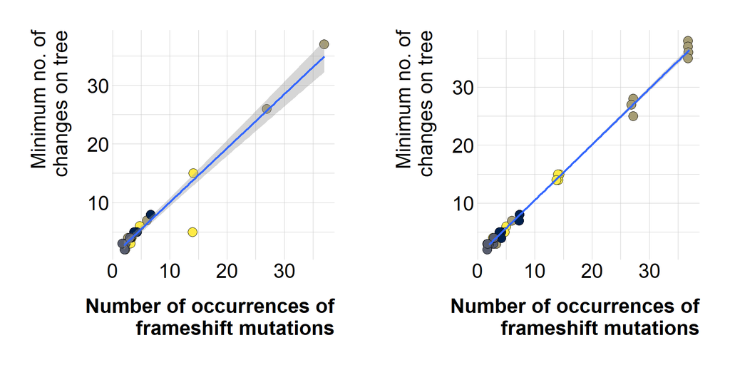

```r
Fig4B_2<-ggplot(data=CC_reps_ci_SHUF[CC_reps_ci_SHUF$fs_counts>1,])+
  geom_point(aes(x=fs_counts,y=as.numeric(MinimumNumberChangesOnTree),fill=CC),size=4,shape=21,position = position_jitter(width = 0.35,height=0.01),color="black")+
  geom_smooth(method="lm",formula = y ~ x,aes(x=fs_counts,y=as.numeric(MinimumNumberChangesOnTree)))+
  theme_ipsum(base_family = "Arial")+
  scale_x_continuous(breaks=pretty_breaks(n=5))+
  scale_y_continuous(breaks=pretty_breaks(n=5))+
  theme(axis.text.x=element_text(size=axistextx,color="black"))+
  theme(axis.text.y=element_text(size=axistexty,color="black"))+
  theme(axis.title.x=element_text(size=axistitlex,color="black",face="bold",margin = margin(t = 20, r = 0, b = 0, l = 0)))+
  theme(axis.title.y=element_text(size=axistitley,color="black",margin = margin(t = 0, r = 20, b = 0, l = 0)))+
  theme(legend.position = "none")+
  labs(x="Number of occurrences of\nframeshift mutations",y="Minimum no. of\nchanges on tree")+
  scale_fill_manual(values=cividis(4))

Fig4B<-plot_grid(Fig4B_1,Fig4B_2,ncol=2)


Fig4B
```

```r
ggsave("Fig4/Fig4B.svg",plot=Fig4B,device="svg",height = 6,width = 12)
```

### Supplementals

```r
library(Amelia)
library(dplyr)
library(car)
library(randomForest)
library(data.table)
library(ROCR)
library(caret)
library(xgboost)
library(gt)
library(gtsummary)
library(grid)
library(gridExtra)
```

```r
#SUPPLEMENTAL TABLE S2

#https://www.machinelearningplus.com/machine-learning/caret-package/


#################################################
#dataset
################################################

metadata<-read.table("Supplementals/Staphopia_metadata_stage3.4.txt",header = T, sep=",",na.strings = c("","NA"), fill=FALSE)
metadata<-merge(info[,c(2,13,18)],metadata[,c(1,2,3,19,20,21)],by="ID")

data<-metadata[,2:8]
data<-na.omit(data)

#Remove low frequency factor levels
data<-data %>% group_by(host_body_site.y) %>% filter(n()>=50)
data<-data %>% group_by(host_status.y) %>% filter(n()>=50)
data<-data %>% group_by(host.y) %>% filter(n()>=50)

data$fs<-as.factor(data$fs)
data$gp<-as.factor(data$gp)
data$CC<-as.factor(data$CC)

set.seed(1000)
pos_index<-sample(which(data$fs == "1"),400)
neg_index<-sample(which(data$fs == "0"),400)
indexes<-c(pos_index,neg_index)

train<-data[indexes,]
test<-data[-indexes,]

#################################################
#CLASSIFIER
################################################

#10 fold cross validation

control <- trainControl(method="repeatedcv", number=10,repeats=3)
train_metric<-'Kappa'

rf_classifier <- train(fs~., data=train, method="rf", trControl=control,metric=train_metric)

glm_classifier <- train(fs~., data=train, method="glm", trControl=control,metric=train_metric)

xgb_classifier <- train(fs~., data=train, method="xgbTree", trControl=control,metric=train_metric)

knn_classifier <- train(fs~., data=train, method="knn", trControl=control,metric=train_metric)

rf_predict<-predict(rf_classifier,test)
glm_predict<-predict(glm_classifier,test)
xgb_predict<-predict(xgb_classifier,test)
knn_predict<-predict(knn_classifier,test)

#confusionMatrix(reference=test$fs,data=rf_predict,mode='everything',positive = "1")
#confusionMatrix(reference=test$fs,data=xgb_predict,mode='everything',positive = "1")
#confusionMatrix(reference=test$fs,data=glm_predict,mode='everything',positive = "1")
#confusionMatrix(reference=test$fs,data=knn_predict,mode='everything',positive = "1")

summary_classifiers<-as.data.frame(cbind((as.matrix(confusionMatrix(reference=test$fs,data=glm_predict,mode='everything',positive = "1"),what="classes")),(as.matrix(confusionMatrix(reference=test$fs,data=,rf_predict,mode='everything',positive = "1"),what="classes")),(as.matrix(confusionMatrix(reference=test$fs,data=xgb_predict,mode='everything',positive = "1"),what="classes")),(as.matrix(confusionMatrix(reference=test$fs,data=knn_predict,mode='everything',positive = "1"),what="classes"))))

colnames(summary_classifiers)<-c("GLM","RF","XGB","KNN")

numeric_columns <- sapply(summary_classifiers, mode) == 'numeric'
summary_classifiers[numeric_columns] <-  round(summary_classifiers[numeric_columns], 3)

write.table(summary_classifiers,file="Supplementals/TableS2.csv",quote=F,row.names=T,col.names=T,sep=",")

models_compare<-resamples(list(GLM=glm_classifier,RF=rf_classifier,XGB=xgb_classifier,KNN=knn_classifier))
summary(models_compare)
```

```
##
## Call:
## summary.resamples(object = models_compare)
##
## Models: GLM, RF, XGB, KNN
## Number of resamples: 30
##
## Accuracy
##       Min.  1st Qu.  Median      Mean  3rd Qu.   Max. NA's
## GLM 0.4625 0.525000 0.55625 0.5566667 0.587500 0.6625    0
## RF  0.5250 0.578125 0.63125 0.6262500 0.671875 0.7250    0
## XGB 0.5375 0.587500 0.62500 0.6254167 0.671875 0.7375    0
## KNN 0.4875 0.575000 0.61250 0.6200000 0.662500 0.7375    0
##
## Kappa
##       Min. 1st Qu. Median      Mean 3rd Qu.  Max. NA's
## GLM -0.075 0.05000 0.1125 0.1133333 0.17500 0.325    0
## RF   0.050 0.15625 0.2625 0.2525000 0.34375 0.450    0
## XGB  0.075 0.17500 0.2500 0.2508333 0.34375 0.475    0
## KNN -0.025 0.15000 0.2250 0.2400000 0.32500 0.475    0
```

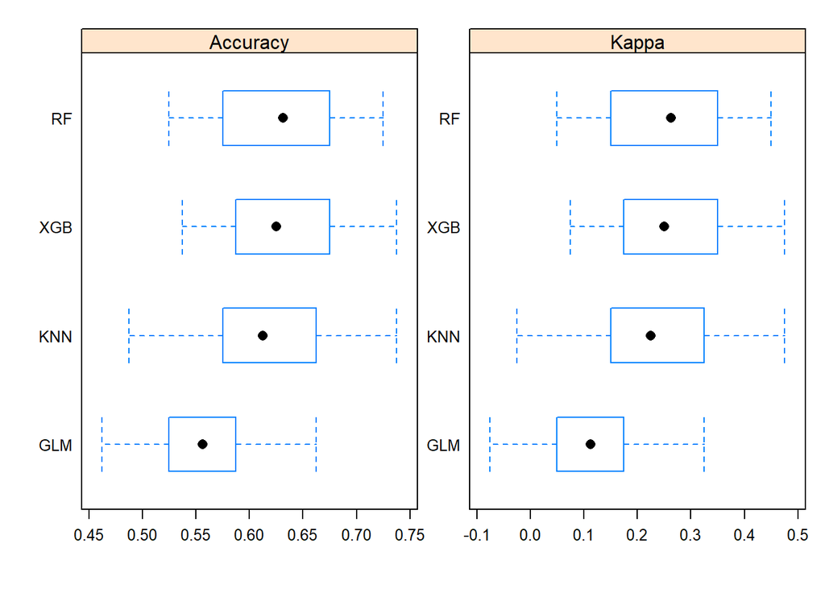

```r
scales <- list(x=list(relation="free"), y=list(relation="free"))
bwplot(models_compare, scales=scales)
```

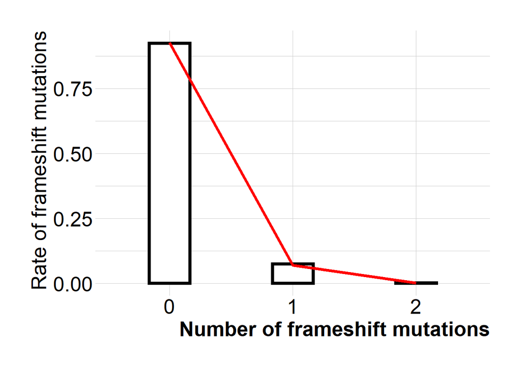

```r
# SUPPLEMENTAL FIG S4

#39174 operons with KNOWN frameshift status
#2997 KNOWN fs mutations

#Rate of occurrence of fs = 2997/39174 = 0.07650482462 = lambda

mut_rates<-data.frame(table(info$no_fs[info$no_fs!="u"]))
mut_rates$expected_Freq<-dpois(0:2, lambda=0.07650482462)
mut_rates$actual_Freq<-mut_rates$Freq/sum(mut_rates$Freq)


FigS4<-ggplot(data=mut_rates,aes(x=Var1,y=expected_Freq))+
  geom_histogram(data=mut_rates,aes(x=Var1,y=actual_Freq),stat="identity",color="black",fill="white",size=1.5,width=0.33)+
  geom_line(data=mut_rates,aes(x=Var1,y=expected_Freq,group=1),color="red",size=1.4)+
  theme_ipsum(base_family = "Arial")+
  theme(axis.text.x=element_text(size=axistextx,color="black"))+
  theme(axis.text.y=element_text(size=axistexty,color="black"))+
  theme(axis.title.x=element_text(size=axistitlex,color="black",face="bold"))+
  theme(axis.title.y=element_text(size=axistitley,color="black"))+
  xlab("Number of frameshift mutations")+
  ylab("Rate of frameshift mutations")

ggsave("Supplementals/FigS4.svg",plot=FigS4,device="svg",height = 6,width = 6)

FigS4
```

```r
colnames(mut_rates)<-c("No. of fs","Frequency","Expected Rate (poisson)","Actual rate")

mut_rates
```

```
##   No. of fs Frequency Expected Rate (poisson) Actual rate
## 1         0     36177             0.926348445 0.923495175
## 2         1      2906             0.070870125 0.074181855
## 3         2        91             0.002710953 0.002322969
```

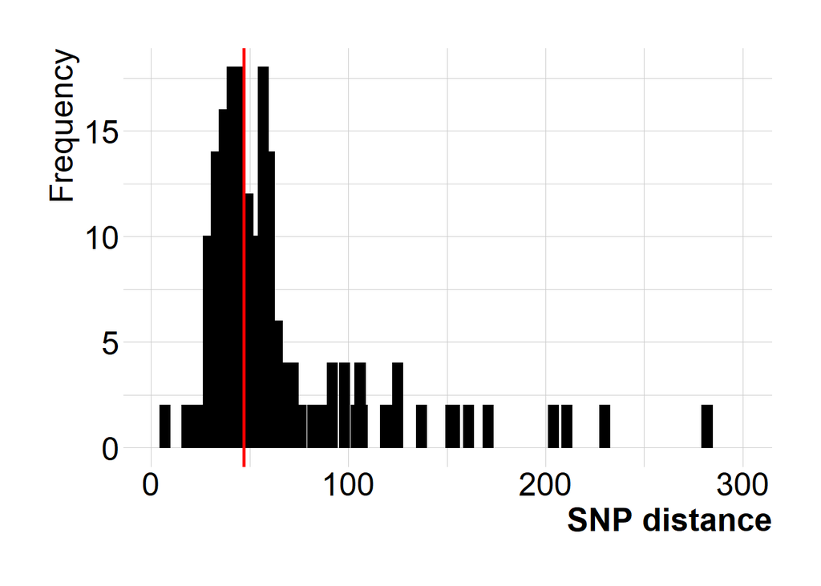

```r
#SUPPLEMENTAL FIG S5
snpdist<-read.table("Supplementals/nrd_snp-dists.txt",header=F,sep="\t")
mashdist<-read.table("Supplementals/nrd_mash_dist.txt",header=F,sep="\t")


colnames(snpdist)<-c("acc1","acc2","snp_dist")
colnames(mashdist)<-c("acc1","acc2","mash_dist","p","score")

dists<-merge(mashdist,snpdist,by=c("acc1","acc2"))

FigS5<-ggplot(data=dists[dists$mash_dist<0.0005,],aes(x=snp_dist))+
  geom_histogram(stat="count",color="black",fill="black",width=5)+
  theme_ipsum(base_family = "Arial")+
  theme(axis.text.x=element_text(size=axistextx,color="black"))+
  theme(axis.text.y=element_text(size=axistexty,color="black"))+
  theme(axis.title.x=element_text(size=axistitlex,color="black",face="bold"))+
  theme(axis.title.y=element_text(size=axistitley,color="black"))+
  xlab("SNP distance")+
  ylab("Frequency")+
  geom_vline(xintercept = median(dists$snp_dist[dists$mash_dist<0.0005 & dists$snp_dist!=0]),color="red",size=1)+
  xlim(1,300)

ggsave("Supplementals/FigS5.svg",plot=FigS5,device="svg",height = 6,width = 6)

FigS5
```